# Assignment 4: k-Means Clustering

Steve Lamber

2026-06-02

## Introduction

The purpose of this assignment is to use k-means clustering to explore the structure of the pharmaceutical industry using financial measures. The dataset contains 21 pharmaceutical firms and includes financial variables such as market capitalization, beta, price/earnings ratio, return on equity, return on assets, asset turnover, leverage, revenue growth, and net profit margin. It also includes variables not used in the clustering process, such as median recommendation, headquarters location, and stock exchange.

For the clustering model, I used only the first nine numerical variables listed in the assignment instructions. The remaining variables were used after the clusters were created to help interpret whether there were any patterns by recommendation, location, or exchange.

## Load the Data

```r
pharma <- read.csv("Pharmaceuticals.csv")

str(pharma)
```

```
## 'data.frame':    21 obs. of  14 variables:
##  $ Symbol               : chr  "ABT" "AGN" "AHM" "AZN" ...
##  $ Name                 : chr  "Abbott Laboratories" "Allergan, Inc." "Amersham plc" "AstraZeneca PLC" ...
##  $ Market_Cap           : num  68.44 7.58 6.3 67.63 47.16 ...
##  $ Beta                 : num  0.32 0.41 0.46 0.52 0.32 1.11 0.5 0.85 1.08 0.18 ...
##  $ PE_Ratio             : num  24.7 82.5 20.7 21.5 20.1 27.9 13.9 26 3.6 27.9 ...
##  $ ROE                  : num  26.4 12.9 14.9 27.4 21.8 3.9 34.8 24.1 15.1 31 ...
##  $ ROA                  : num  11.8 5.5 7.8 15.4 7.5 1.4 15.1 4.3 5.1 13.5 ...
##  $ Asset_Turnover       : num  0.7 0.9 0.9 0.9 0.6 0.6 0.9 0.6 0.3 0.6 ...
##  $ Leverage             : num  0.42 0.6 0.27 0 0.34 0 0.57 3.51 1.07 0.53 ...
##  $ Rev_Growth           : num  7.54 9.16 7.05 15 26.81 ...
##  $ Net_Profit_Margin    : num  16.1 5.5 11.2 18 12.9 2.6 20.6 7.5 13.3 23.4 ...
##  $ Median_Recommendation: chr  "Moderate Buy" "Moderate Buy" "Strong Buy" "Moderate Sell" ...
##  $ Location             : chr  "US" "CANADA" "UK" "UK" ...
##  $ Exchange             : chr  "NYSE" "NYSE" "NYSE" "NYSE" ...
```

```r
head(pharma)
```

```
##   Symbol                Name Market_Cap Beta PE_Ratio  ROE  ROA Asset_Turnover
## 1    ABT Abbott Laboratories      68.44 0.32     24.7 26.4 11.8            0.7
## 2    AGN      Allergan, Inc.       7.58 0.41     82.5 12.9  5.5            0.9
## 3    AHM        Amersham plc       6.30 0.46     20.7 14.9  7.8            0.9
## 4    AZN     AstraZeneca PLC      67.63 0.52     21.5 27.4 15.4            0.9
## 5    AVE             Aventis      47.16 0.32     20.1 21.8  7.5            0.6
## 6    BAY            Bayer AG      16.90 1.11     27.9  3.9  1.4            0.6
##   Leverage Rev_Growth Net_Profit_Margin Median_Recommendation Location Exchange
## 1     0.42       7.54              16.1          Moderate Buy       US     NYSE
## 2     0.60       9.16               5.5          Moderate Buy   CANADA     NYSE
## 3     0.27       7.05              11.2            Strong Buy       UK     NYSE
## 4     0.00      15.00              18.0         Moderate Sell       UK     NYSE
## 5     0.34      26.81              12.9          Moderate Buy   FRANCE     NYSE
## 6     0.00      -3.17               2.6                  Hold  GERMANY     NYSE
```

## Select Numerical Variables for Clustering

The assignment asks us to cluster the firms using only the numerical financial variables 1 through 9. These are market capitalization, beta, price/earnings ratio, return on equity, return on assets, asset turnover, leverage, estimated revenue growth, and net profit margin.

```r
numeric_vars <- c(
  "Market_Cap",
  "Beta",
  "PE_Ratio",
  "ROE",
  "ROA",
  "Asset_Turnover",
  "Leverage",
  "Rev_Growth",
  "Net_Profit_Margin"
)

pharma_numeric <- pharma[, numeric_vars]

summary(pharma_numeric)
```

```
##    Market_Cap          Beta           PE_Ratio          ROE
##  Min.   :  0.41   Min.   :0.1800   Min.   : 3.60   Min.   : 3.9
##  1st Qu.:  6.30   1st Qu.:0.3500   1st Qu.:18.90   1st Qu.:14.9
##  Median : 48.19   Median :0.4600   Median :21.50   Median :22.6
##  Mean   : 57.65   Mean   :0.5257   Mean   :25.46   Mean   :25.8
##  3rd Qu.: 73.84   3rd Qu.:0.6500   3rd Qu.:27.90   3rd Qu.:31.0
##  Max.   :199.47   Max.   :1.1100   Max.   :82.50   Max.   :62.9
##       ROA        Asset_Turnover    Leverage        Rev_Growth
##  Min.   : 1.40   Min.   :0.3    Min.   :0.0000   Min.   :-3.17
##  1st Qu.: 5.70   1st Qu.:0.6    1st Qu.:0.1600   1st Qu.: 6.38
##  Median :11.20   Median :0.6    Median :0.3400   Median : 9.37
##  Mean   :10.51   Mean   :0.7    Mean   :0.5857   Mean   :13.37
##  3rd Qu.:15.00   3rd Qu.:0.9    3rd Qu.:0.6000   3rd Qu.:21.87
##  Max.   :20.30   Max.   :1.1    Max.   :3.5100   Max.   :34.21
##  Net_Profit_Margin
##  Min.   : 2.6
##  1st Qu.:11.2
##  Median :16.1
##  Mean   :15.7
##  3rd Qu.:21.1
##  Max.   :25.5
```

## Standardize the Numerical Variables

The numerical variables are measured on very different scales. For example, market capitalization is measured in billions of dollars, while beta and leverage are much smaller values. Since k-means uses distance calculations, variables with larger scales can dominate the clustering if the data is not standardized.

For that reason, I standardized all nine numerical variables using z-score standardization. I did not apply additional manual weights to the variables. This gives each financial measure an equal opportunity to influence the clustering result.

```r
pharma_scaled <- scale(pharma_numeric)

summary(pharma_scaled)
```

```
##    Market_Cap           Beta            PE_Ratio            ROE
##  Min.   :-0.9768   Min.   :-1.3466   Min.   :-1.3404   Min.   :-1.4515
##  1st Qu.:-0.8763   1st Qu.:-0.6844   1st Qu.:-0.4023   1st Qu.:-0.7223
##  Median :-0.1614   Median :-0.2560   Median :-0.2429   Median :-0.2118
##  Mean   : 0.0000   Mean   : 0.0000   Mean   : 0.0000   Mean   : 0.0000
##  3rd Qu.: 0.2762   3rd Qu.: 0.4841   3rd Qu.: 0.1495   3rd Qu.: 0.3450
##  Max.   : 2.4200   Max.   : 2.2758   Max.   : 3.4971   Max.   : 2.4597
##       ROA          Asset_Turnover       Leverage          Rev_Growth
##  Min.   :-1.7128   Min.   :-1.8451   Min.   :-0.74966   Min.   :-1.4971
##  1st Qu.:-0.9047   1st Qu.:-0.4613   1st Qu.:-0.54487   1st Qu.:-0.6328
##  Median : 0.1289   Median :-0.4613   Median :-0.31449   Median :-0.3621
##  Mean   : 0.0000   Mean   : 0.0000   Mean   : 0.00000   Mean   : 0.0000
##  3rd Qu.: 0.8430   3rd Qu.: 0.9225   3rd Qu.: 0.01828   3rd Qu.: 0.7693
##  Max.   : 1.8389   Max.   : 1.8451   Max.   : 3.74280   Max.   : 1.8862
##  Net_Profit_Margin
##  Min.   :-1.99560
##  1st Qu.:-0.68504
##  Median : 0.06168
##  Mean   : 0.00000
##  3rd Qu.: 0.82364
##  Max.   : 1.49416
```

## Choosing the Number of Clusters

The main tuning choice in k-means is the number of clusters, k. I evaluated possible values of k using the elbow method and the average silhouette method.

The elbow method looks at the total within-cluster sum of squares. As k increases, within-cluster variation should decrease, but the goal is to choose a value where additional clusters provide a smaller improvement.

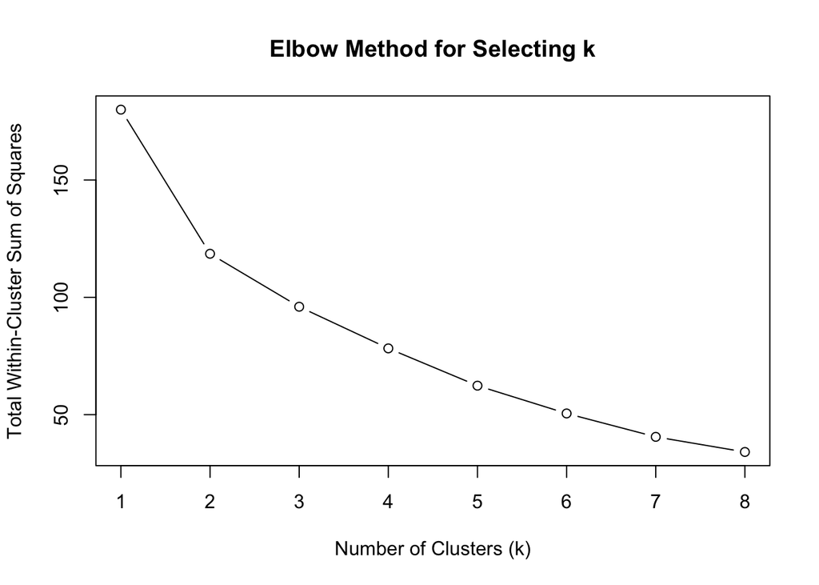

```r
set.seed(123)

wss <- numeric(8)

for (k in 1:8) {
  kmeans_model <- kmeans(pharma_scaled, centers = k, nstart = 50)
  wss[k] <- kmeans_model$tot.withinss
}

plot(
  1:8,
  wss,
  type = "b",
  xlab = "Number of Clusters (k)",
  ylab = "Total Within-Cluster Sum of Squares",
  main = "Elbow Method for Selecting k"
)
```

```r
wss_table <- data.frame(
  k = 1:8,
  WSS = round(wss, 3)
)

knitr::kable(wss_table)
```

| k | WSS |
| --- | --- |
| 1 | 180.000 |
| 2 | 118.569 |
| 3 | 95.994 |
| 4 | 78.246 |
| 5 | 62.354 |
| 6 | 50.510 |
| 7 | 40.539 |
| 8 | 34.096 |

The silhouette method measures how well each observation fits within its assigned cluster compared with other clusters. Higher average silhouette values suggest a better clustering structure.

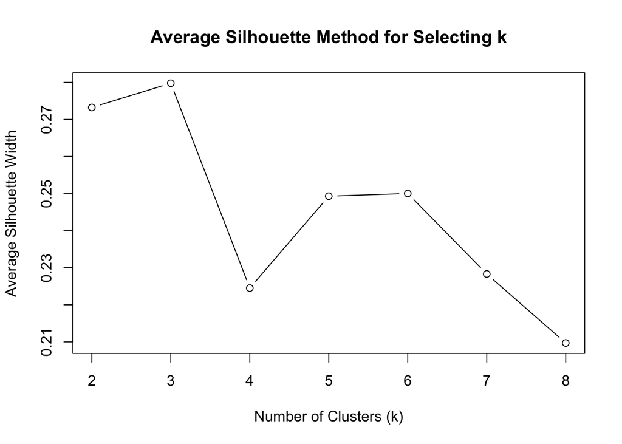

```r
library(cluster)

silhouette_values <- numeric(7)

for (k in 2:8) {
  kmeans_model <- kmeans(pharma_scaled, centers = k, nstart = 50)
  silhouette_result <- silhouette(kmeans_model$cluster, dist(pharma_scaled))
  silhouette_values[k - 1] <- mean(silhouette_result[, 3])
}

plot(
  2:8,
  silhouette_values,
  type = "b",
  xlab = "Number of Clusters (k)",
  ylab = "Average Silhouette Width",
  main = "Average Silhouette Method for Selecting k"
)
```

```r
silhouette_table <- data.frame(
  k = 2:8,
  Average_Silhouette = round(silhouette_values, 3)
)

knitr::kable(silhouette_table)
```

| k | Average_Silhouette |
| --- | --- |
| 2 | 0.273 |
| 3 | 0.280 |
| 4 | 0.225 |
| 5 | 0.249 |
| 6 | 0.250 |
| 7 | 0.228 |
| 8 | 0.210 |

Based on the elbow and silhouette results, I selected k = 3. This choice provides an interpretable number of clusters for a small dataset of only 21 firms. A larger number of clusters would create very small groups, which may be harder to interpret and may overfit the specific sample.

## Run the k-Means Model

I used k-means clustering with k = 3. Because k-means can produce different results depending on its random starting points, I set a random seed and used 50 random starts.

```r
set.seed(123)

final_k <- 3

kmeans_final <- kmeans(pharma_scaled, centers = final_k, nstart = 50)

pharma$Cluster <- as.factor(kmeans_final$cluster)

kmeans_final$size
```

```
## [1]  4 11  6
```

```r
kmeans_final$centers
```

```
##   Market_Cap       Beta   PE_Ratio        ROE        ROA Asset_Turnover
## 1 -0.6125361  0.2698666  1.3143935 -0.9609057 -1.0174553      0.2306328
## 2  0.6733825 -0.3586419 -0.2763512  0.6565978  0.8344159      0.4612656
## 3 -0.8261772  0.4775991 -0.3696184 -0.5631589 -0.8514589     -0.9994088
##     Leverage Rev_Growth Net_Profit_Margin
## 1 -0.3592866 -0.5757385        -1.3784169
## 2 -0.3331068 -0.2902163         0.6823310
## 3  0.8502201  0.9158889        -0.3319956
```

## Cluster Membership

```r
cluster_membership <- pharma[, c("Cluster", "Symbol", "Name", "Median_Recommendation", "Location", "Exchange")]
cluster_membership <- cluster_membership[order(cluster_membership$Cluster, cluster_membership$Symbol), ]

knitr::kable(cluster_membership)
```

|  | Cluster | Symbol | Name | Median_Recommendation | Location | Exchange |
| --- | --- | --- | --- | --- | --- | --- |
| 2 | 1 | AGN | Allergan, Inc. | Moderate Buy | CANADA | NYSE |
| 3 | 1 | AHM | Amersham plc | Strong Buy | UK | NYSE |
| 6 | 1 | BAY | Bayer AG | Hold | GERMANY | NYSE |
| 18 | 1 | PHA | Pharmacia Corporation | Hold | US | NYSE |
| 1 | 2 | ABT | Abbott Laboratories | Moderate Buy | US | NYSE |
| 4 | 2 | AZN | AstraZeneca PLC | Moderate Sell | UK | NYSE |
| 7 | 2 | BMY | Bristol-Myers Squibb Company | Moderate Sell | US | NYSE |
| 11 | 2 | GSK | GlaxoSmithKline plc | Hold | UK | NYSE |
| 13 | 2 | JNJ | Johnson & Johnson | Moderate Buy | US | NYSE |
| 10 | 2 | LLY | Eli Lilly and Company | Hold | US | NYSE |
| 15 | 2 | MRK | Merck & Co., Inc. | Hold | US | NYSE |
| 16 | 2 | NVS | Novartis AG | Hold | SWITZERLAND | NYSE |
| 17 | 2 | PFE | Pfizer Inc | Moderate Buy | US | NYSE |
| 19 | 2 | SGP | Schering-Plough Corporation | Hold | US | NYSE |
| 21 | 2 | WYE | Wyeth | Hold | US | NYSE |
| 5 | 3 | AVE | Aventis | Moderate Buy | FRANCE | NYSE |
| 8 | 3 | CHTT | Chattem, Inc | Moderate Buy | US | NASDAQ |
| 9 | 3 | ELN | Elan Corporation, plc | Moderate Sell | IRELAND | NYSE |
| 12 | 3 | IVX | IVAX Corporation | Hold | US | AMEX |
| 14 | 3 | MRX | Medicis Pharmaceutical Corporation | Moderate Buy | US | NYSE |
| 20 | 3 | WPI | Watson Pharmaceuticals, Inc. | Moderate Sell | US | NYSE |

## Interpret the Clusters Using Numerical Variables

The table below shows the average values of the nine numerical variables for each cluster. These values are based on the original units, which makes the clusters easier to interpret.

```r
cluster_means <- aggregate(pharma_numeric, by = list(Cluster = pharma$Cluster), mean)

cluster_means_display <- cluster_means
cluster_means_display[, numeric_vars] <- round(cluster_means_display[, numeric_vars], 2)

knitr::kable(cluster_means_display)
```

| Cluster | Market_Cap | Beta | PE_Ratio | ROE | ROA | Asset_Turnover | Leverage | Rev_Growth | Net_Profit_Margin |
| --- | --- | --- | --- | --- | --- | --- | --- | --- | --- |
| 1 | 21.75 | 0.60 | 46.90 | 11.3 | 5.10 | 0.75 | 0.30 | 7.01 | 6.65 |
| 2 | 97.11 | 0.43 | 20.95 | 35.7 | 14.95 | 0.80 | 0.33 | 10.16 | 20.17 |
| 3 | 9.23 | 0.65 | 19.43 | 17.3 | 5.98 | 0.48 | 1.25 | 23.49 | 13.52 |

The table below shows the cluster centers on the standardized scale. Positive values indicate that the cluster is above the dataset average for that variable, while negative values indicate that the cluster is below average.

```r
standardized_centers <- data.frame(
  Cluster = as.factor(1:final_k),
  round(kmeans_final$centers, 2)
)

knitr::kable(standardized_centers)
```

| Cluster | Market_Cap | Beta | PE_Ratio | ROE | ROA | Asset_Turnover | Leverage | Rev_Growth | Net_Profit_Margin |
| --- | --- | --- | --- | --- | --- | --- | --- | --- | --- |
| 1 | -0.61 | 0.27 | 1.31 | -0.96 | -1.02 | 0.23 | -0.36 | -0.58 | -1.38 |
| 2 | 0.67 | -0.36 | -0.28 | 0.66 | 0.83 | 0.46 | -0.33 | -0.29 | 0.68 |
| 3 | -0.83 | 0.48 | -0.37 | -0.56 | -0.85 | -1.00 | 0.85 | 0.92 | -0.33 |

## Assign Descriptive Cluster Names

To make the results easier to interpret, I assigned descriptive names based on the financial profile of each cluster. The cluster with the highest average market capitalization and strong profitability is labeled as large profitable established firms. The cluster with the highest beta and leverage is labeled as small high-risk growth firms. The remaining cluster is labeled as mid-sized valuation or transition firms.

```r
cluster_summary <- aggregate(pharma_numeric, by = list(Cluster = pharma$Cluster), mean)

large_profitable_cluster <- cluster_summary$Cluster[
  which.max(scale(cluster_summary$Market_Cap)[,1] + scale(cluster_summary$Net_Profit_Margin)[,1] + scale(cluster_summary$ROA)[,1])
]

high_risk_cluster <- cluster_summary$Cluster[
  which.max(scale(cluster_summary$Beta)[,1] + scale(cluster_summary$Leverage)[,1] + scale(cluster_summary$Rev_Growth)[,1])
]

cluster_summary$Cluster_Name <- "Mid-Sized Valuation / Transition Firms"
cluster_summary$Cluster_Name[cluster_summary$Cluster == large_profitable_cluster] <- "Large Profitable Established Firms"
cluster_summary$Cluster_Name[cluster_summary$Cluster == high_risk_cluster] <- "Small High-Risk Growth Firms"

cluster_names <- cluster_summary[, c("Cluster", "Cluster_Name")]

pharma <- merge(pharma, cluster_names, by = "Cluster", all.x = TRUE)

knitr::kable(cluster_names)
```

| Cluster | Cluster_Name |
| --- | --- |
| 1 | Mid-Sized Valuation / Transition Firms |
| 2 | Large Profitable Established Firms |
| 3 | Small High-Risk Growth Firms |

## Cluster Interpretation

```r
final_cluster_summary <- aggregate(
  pharma[, numeric_vars],
  by = list(Cluster_Name = pharma$Cluster_Name),
  mean
)

final_cluster_summary_display <- final_cluster_summary
final_cluster_summary_display[, numeric_vars] <- round(final_cluster_summary_display[, numeric_vars], 2)

knitr::kable(final_cluster_summary_display)
```

| Cluster_Name | Market_Cap | Beta | PE_Ratio | ROE | ROA | Asset_Turnover | Leverage | Rev_Growth | Net_Profit_Margin |
| --- | --- | --- | --- | --- | --- | --- | --- | --- | --- |
| Large Profitable Established Firms | 97.11 | 0.43 | 20.95 | 35.7 | 14.95 | 0.80 | 0.33 | 10.16 | 20.17 |
| Mid-Sized Valuation / Transition Firms | 21.75 | 0.60 | 46.90 | 11.3 | 5.10 | 0.75 | 0.30 | 7.01 | 6.65 |
| Small High-Risk Growth Firms | 9.23 | 0.65 | 19.43 | 17.3 | 5.98 | 0.48 | 1.25 | 23.49 | 13.52 |

The large profitable established firms cluster is characterized by larger market capitalization and stronger profitability measures such as return on equity, return on assets, and net profit margin. These firms appear to represent the more established pharmaceutical companies in the dataset.

The mid-sized valuation or transition firms cluster generally has lower profitability than the large profitable group and tends to show higher price/earnings ratios. This may suggest firms that investors value based on future expectations or firms that are in a less mature financial position compared with the strongest large-cap companies.

The small high-risk growth firms cluster is characterized by smaller market capitalization, higher beta, higher leverage, and higher revenue growth. These firms appear to be more volatile and potentially more growth-oriented, but also riskier from a financial perspective.

## Patterns in Variables Not Used in Clustering

The variables not used in forming the clusters were Median_Recommendation, Location, and Exchange. These variables can help determine whether the financial clusters align with analyst sentiment, geography, or stock listing.

```r
recommendation_table <- table(pharma$Cluster_Name, pharma$Median_Recommendation)
location_table <- table(pharma$Cluster_Name, pharma$Location)
exchange_table <- table(pharma$Cluster_Name, pharma$Exchange)

recommendation_table
```

```
##
##                                          Hold Moderate Buy Moderate Sell
##   Large Profitable Established Firms        6            3             2
##   Mid-Sized Valuation / Transition Firms    2            1             0
##   Small High-Risk Growth Firms              1            3             2
##
##                                          Strong Buy
##   Large Profitable Established Firms              0
##   Mid-Sized Valuation / Transition Firms          1
##   Small High-Risk Growth Firms                    0
```

```r
location_table
```

```
##
##                                          CANADA FRANCE GERMANY IRELAND
##   Large Profitable Established Firms          0      0       0       0
##   Mid-Sized Valuation / Transition Firms      1      0       1       0
##   Small High-Risk Growth Firms                0      1       0       1
##
##                                          SWITZERLAND UK US
##   Large Profitable Established Firms               1  2  8
##   Mid-Sized Valuation / Transition Firms           0  1  1
##   Small High-Risk Growth Firms                     0  0  4
```

```r
exchange_table
```

```
##
##                                          AMEX NASDAQ NYSE
##   Large Profitable Established Firms        0      0   11
##   Mid-Sized Valuation / Transition Firms    0      0    4
##   Small High-Risk Growth Firms              1      1    4
```

The recommendation table shows whether analyst recommendations differ across the clusters. The location table shows whether firms from certain countries are concentrated in specific clusters. The exchange table shows whether the clusters align with where the firms are listed.

In this dataset, the clearest non-financial pattern is related to exchange listing. The higher-risk smaller firms include the non-NYSE firms in the dataset, while the larger established companies are mostly listed on the NYSE. Location and recommendation appear more mixed, meaning the clusters are mainly driven by financial structure rather than geography or analyst recommendation alone.

## Conclusion

The k-means clustering analysis produced three interpretable groups of pharmaceutical firms. The data was standardized before clustering so that all numerical variables had equal weight in the distance calculations. The final model used k = 3 because it provided a useful balance between model simplicity and interpretability for a small dataset.

The clusters can be summarized as large profitable established firms, mid-sized valuation or transition firms, and small high-risk growth firms. These groups differ mainly by market capitalization, profitability, leverage, beta, and revenue growth. The variables that were not used to form the clusters showed some additional patterns, especially exchange listing, but the main cluster structure was based on the numerical financial measures.